# Error rates in experimental neuroscience

Bindoff, A.

25 May 2018

Abstract

A Monte Carlo simulation study evaluating the Type 1 and Type 2 error rates for a range of experimental designs and plausible parameters.

## Packages and helper functions

```r
library(magrittr)
library(dplyr)
library(ggplot2)
library(lme4)
library(gridExtra)
library(lmerTest)
library(viridis)
library(ggbeeswarm)
library(purrr)
library(mgcv)


# `expand.grid.df` works like `expand.grid` but enables the user to define paired columns
# it will return every combination of each argument
expand.grid.df <- function(...) Reduce(function(...) merge(..., by=NULL), list(...))

# `%nin%` "not in", e.g c("a", "b", "c") %nin% c("a", "c") will return "b"
`%nin%` <- Negate(`%in%`)
```

### Plot method

This is a generic plot method to nicely format data from simulated experiments with simulated random effects.

```r
# generic plot method
plot.sim <- function(d){
  ggplot(d, aes(x = condition, y = y, colour = animal.id, fill = animal.id)) +
    geom_quasirandom(dodge.width = 1, alpha = 1/2, size = 2) +
    geom_point(aes(y = y.mean, group = animal.id), colour = "black", size = 4, position = position_dodge(width = 1), shape = 3)
}

# method for extracting a legend to use in grid.arrange
get_legend<-function(myggplot){
    tmp <- ggplot_gtable(ggplot_build(myggplot))
    leg <- which(sapply(tmp$grobs, function(x) x$name) == "guide-box")
    legend <- tmp$grobs[[leg]]
    return(legend)
    }
```

### Simulation method

`sim.mm` will simulate a dataset with parameters specifying the number of replicates, the number of pseudoreplicates, any number of fixed effects, and variance for random effects and the error term. It assumes one treatment and one control group. If the variance for the error term is not specified it will return a data frame without simulated data. If `random.assignment` = F it will return data from a nested (split-plot) design. For simplicity, `n.replicates` must be an even number.

```r
# if sd.error is specified, `sim.mm` will simulate data with
# fixed and random effects and their parameters, otherwise
# a data.frame is returned with y-hat but no residuals
# if random.assignment = F, will simulate data from a nested (split-plot) design
# so there will be twice as many observations (need to consider this if estimating
# the power of two different designs)
sim.mm <- function(...,
                   n.replicates = 4,
                   sd.random = 0.5,
                   fixed.effects = 0,
                   n.pseudo = 3,
                   random.assignment = T,
                   sd.error = NULL){
  animals <- data.frame(animal.id = as.factor(seq(n.replicates)),
                        random.effect = rnorm(n.replicates, 0, sd.random))
  conditions <- data.frame(condition = c("contr", "exp"),
                           fixed.effect = c(0,fixed.effects))
  pseudoreplicate <- data.frame(pseudoreplicate = c(1:n.pseudo))
  d <- expand.grid.df(pseudoreplicate, animals, conditions)
  if(random.assignment){
    i <- sample(unique(d$animal.id), n.replicates/2, replace = FALSE)
    d %<>% filter(xor(animal.id %nin% i, condition == "exp"))
  }
  d %<>% mutate(y.hat = random.effect + fixed.effect)
  if(!is.null(sd.error)){
    d %<>% mutate(y = y.hat + rnorm(nrow(d), 0, sd.error)) %>%
      group_by(animal.id, condition) %>%
      mutate(y.mean = mean(y))
  }
  d
}

# example
# plot.sim(sim.mm(n.replicates = 8, n.pseudo = 5, sd.error = 1/2, sd.random = 1, fixed.effects = 2))
```

### Tests used to compute p-values

p-values for mixed models use Satterthwaite approximation, implemented in the `lmerTest` package. Where the random intercept + random co-efficient model failed to converge, the returned p-value was 1. This is a arguably a methodological flaw, because in practice the analyst may utilise a different optimiser.

```r
tests <- function(x, nested = FALSE){
  m1 <- anova(k <- lm(y ~ condition, data = x))
  m1$effect_size <- diff(coef(k))/sd(resid(k))
  m2 <- anova(k <- lmer(y ~ condition + (1|animal.id), data = x))
  m2$effect_size <- diff(fixef(k))/sd(resid(k))
  m3 <- m2
  if(nested){
    m3 <- tryCatch({anova(lmer(y ~ condition + (condition|animal.id), data = x))}, warning = function(war){
      m3$`Pr(>F)` <- 1
      return(m3)})
  }
  return(cbind(m1$`Pr(>F)`[1], m2$`Pr(>F)`, m3$`Pr(>F)`, m1$effect_size[1], m2$effect_size))
}
```

It would also be helpful to have a method for plotting marginal error rates. `plot.error.rates` takes `data` and a `model` formula, then fits the model using a GAM, generates predictions, and returns a `ggplot2` object for the first two model terms, assuming the first term is continuous and the second term is a factor.

```r
plot.error.rates <- function(data, model){
  m <- gam(model, data = data)
  k <- apply(m$model, 2, unique)
  d <- expand.grid(k[2:length(k)])
  d$fit <- predict(m, d)
  d[,1] <- factor(d[,1])
  p <- ggplot(d, aes_string(x = names(d[2]), y = "fit", colour = names(d[1]))) +
    geom_line(size = 1) +
    geom_hline(yintercept = .05, linetype = "dotted")
}

n.sims <- 25000
```

# Type 1 error rates - Randomized controlled trial

Compare Type 1 error rates for fixed-effects linear model (`lm` function in R) versus mixed-effects linear model (`lmer` from the `lme4` library in R, with a random co-efficient for each animal) in an RCT with no effect of treatment. Because there is no effect, we can estimate the Type 1 error rate for each method over a range of parameters.

Residuals are clustered on animal. Parameters are specified in code. We generate 2.510^{4} data sets using Monte Carlo simulation over a range of parameters that are “typical” for experimental neuroscience (small number of animals, large number of (pseudo-) replicates.

```r
n.replicates <- floor(runif(n.sims, 6, 50)/2)*2 # even number between 6 and 40
n.pseudo <- sample(c(3:18), n.sims, replace = TRUE)
sd.error <- 1
random.assignment = TRUE
sd.random <- sample(c(0, 0.5, 1, 2), n.sims, replace = TRUE)
fixed.effects <- 0  # no difference between groups
```

```r
sims.meta <- data.frame(n.replicates = n.replicates,
                        n.pseudo = n.pseudo,
                        sd.error = sd.error,
                        random.assignment = random.assignment,
                        sd.random = sd.random,
                        fixed.effects = fixed.effects)

sims <- pmap(sims.meta, sim.mm)  # simulates a data-set using parameters from each row of sims.meta

## let's plot the first of these simulations and compare to the parameters as a sanity check
# plot.sim(sims[[1L]])
# sims.meta[1,]


x <- t(sapply(sims, tests))
sims.meta$lm <- x[,1]
sims.meta$lmer <- x[,2]
sims.meta$lm.d <- x[,4] - sims.meta$fixed.effects
sims.meta$lmer.d <- x[,5] - sims.meta$fixed.effects
save(sims.meta, file = "sims_meta_no_effect_25000.RData")
```

#### Marginal Type 1 error rate:

```r
load("sims_meta_no_effect_25000.RData")
sims.meta %>%
  summarise(type1.lm = mean(lm < .05), type1.lmer = mean(lmer < .05))
```

```
##   type1.lm type1.lmer
## 1  0.30152     0.0496
```

#### Type 1 error rate conditioning on variance of random effects:

```r
sims.meta %>%
  group_by(sd.random) %>%
  summarise(type1.lm = mean(lm < .05), type1.lmer = mean(lmer < .05))
```

```
## # A tibble: 4 x 3
##   sd.random type1.lm type1.lmer
##       <dbl>    <dbl>      <dbl>
## 1     0.      0.0549     0.0396
## 2     0.500   0.254      0.0514
## 3     1.00    0.407      0.0520
## 4     2.00    0.489      0.0556
```

Clearly, the mixed model (`lmer`) produces more acceptable Type 1 error rates for these sorts of experiments.

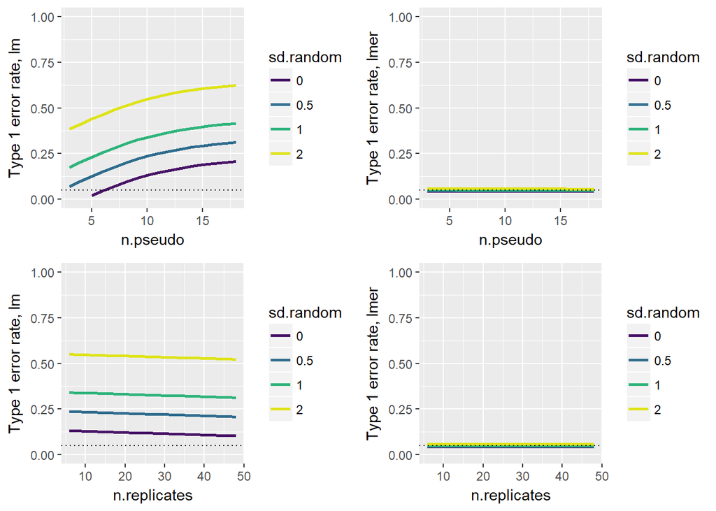

```r
p1 <- plot.error.rates(sims.meta, formula("as.numeric(lm < .05) ~ s(n.pseudo) + sd.random")) +
  ylab("Type 1 error rate, lm") +
  ylim(0, 1)
p2 <- plot.error.rates(sims.meta, formula("as.numeric(lmer < .05) ~ s(n.pseudo) + sd.random")) +
  ylab("Type 1 error rate, lmer") +
  ylim(0, 1)
p3 <- plot.error.rates(sims.meta, formula("as.numeric(lm < .05) ~ s(n.replicates) + sd.random")) +
  ylab("Type 1 error rate, lm") +
  ylim(0, 1)
p4 <- plot.error.rates(sims.meta, formula("as.numeric(lmer < .05) ~ s(n.replicates) + sd.random")) +
  ylab("Type 1 error rate, lmer") +
  ylim(0, 1)

grid.arrange(p1, p2, p3, p4, ncol = 2)
```

`lm` can’t distinguish between replicates and pseudoreplicates (at least not the way we have specified the model), so it effectively “sees” `n.pseudo` x `n.replicates` = `n.tot` total replicates.

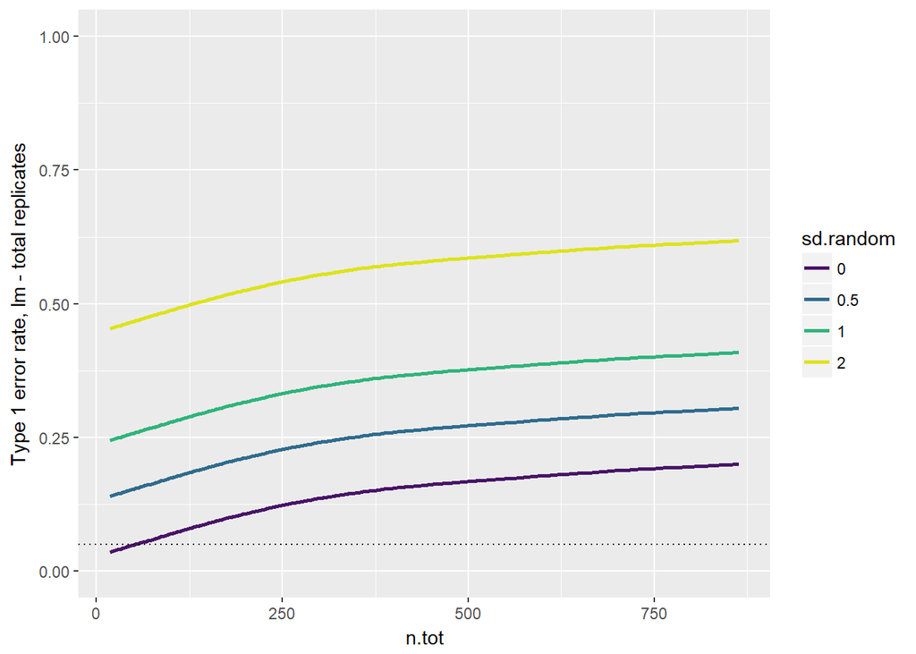

```r
sims.meta$n.tot <- sims.meta$n.pseudo*sims.meta$n.replicates
plot.error.rates(sims.meta, formula("as.numeric(lm < .05) ~ s(n.tot) + sd.random")) +
  ylab("Type 1 error rate, lm - total replicates") +
  ylim(0, 1)
```

Pilot studies are often used to estimate effect sizes. Knowing something about the variance of the random effects and the residual errors can tell us something about how reliable our estimated effect sizes might be.

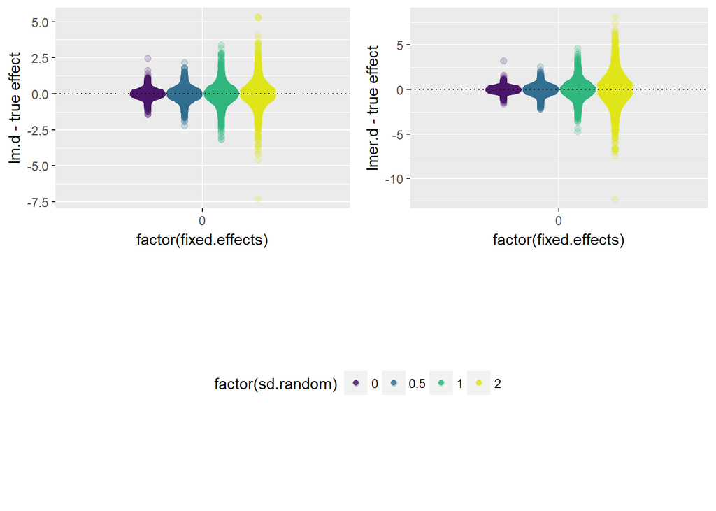

```r
p1 <- ggplot(sims.meta, aes(x = factor(fixed.effects), y = lm.d, colour = factor(sd.random))) +
  geom_quasirandom(dodge.width = 1/2, alpha = 1/5, size = 2) +
  geom_hline(yintercept = 0, linetype = "dotted") +
  theme(legend.position = "none") +
  ylab("lm.d - true effect")
p2 <- ggplot(sims.meta, aes(x = factor(fixed.effects), y = lmer.d, colour = factor(sd.random))) +
  geom_quasirandom(dodge.width = 1/2, alpha = 1/5, size = 2) +
  geom_hline(yintercept = 0, linetype = "dotted") +
  theme(legend.position = "none") +
  ylab("lmer.d - true effect")
p_leg <- get_legend(p2 + geom_point(alpha = 4/5) + theme(legend.position = "bottom"))
grid.arrange(p1, p2, p_leg, layout_matrix = rbind(c(1,2), c(3)))
```

# Type 2 error rates - Randomized controlled trial

We duplicate the parameters of the above experiment, but over a range of effect sizes. This enables an estimate of Type 2 error rates.

```r
fixed.effects <- sample(c(0.1, 0.5, 1, 2), n.sims, replace = T)

sims.meta <- data.frame(n.replicates = n.replicates,
                   n.pseudo = n.pseudo,
                   sd.error = sd.error,
                   random.assignment = random.assignment,
                   sd.random = sd.random,
                   fixed.effects = fixed.effects)

sims <- pmap(sims.meta, sim.mm)  # simulates a data-set using parameters from each row of sims.meta

x <- t(sapply(sims, tests))
sims.meta$lm <- x[,1]
sims.meta$lmer <- x[,2]
sims.meta$lm.d <- x[,4] - sims.meta$fixed.effects
sims.meta$lmer.d <- x[,5] - sims.meta$fixed.effects
save(sims.meta, file = "sims_meta_range_effect_25000.RData")
```

#### Marginal Type 2 error rate:

```r
load("sims_meta_range_effect_25000.RData")
sims.meta %>%
  summarise(type2.lm = mean(lm > .05), type2.lmer = mean(lmer > .05))
```

```
##   type2.lm type2.lmer
## 1    0.265     0.4828
```

#### Type 2 error rate conditioning on variance of random effects:

```r
sims.meta %>%
  group_by(sd.random) %>%
  summarise(type2.lm = mean(lm > .05), type2.lmer = mean(lmer > .05))
```

```
## # A tibble: 4 x 3
##   sd.random type2.lm type2.lmer
##       <dbl>    <dbl>      <dbl>
## 1     0.       0.243      0.263
## 2     0.500    0.240      0.383
## 3     1.00     0.258      0.541
## 4     2.00     0.318      0.742
```

#### Type 2 error rate conditioning on fixed effect size:

```r
sims.meta %>%
  group_by(fixed.effects) %>%
  summarise(type2.lm = mean(lm > .05), type2.lmer = mean(lmer > .05))
```

```
## # A tibble: 4 x 3
##   fixed.effects type2.lm type2.lmer
##           <dbl>    <dbl>      <dbl>
## 1         0.100   0.664       0.926
## 2         0.500   0.276       0.576
## 3         1.00    0.104       0.319
## 4         2.00    0.0201      0.115
```

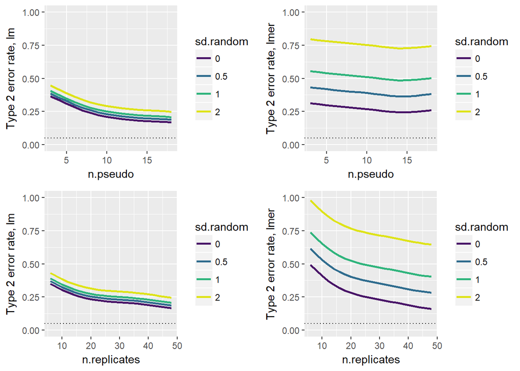

```r
p1 <- plot.error.rates(sims.meta, formula("as.numeric(lm > .05) ~ s(n.pseudo) + sd.random")) +
  ylab("Type 2 error rate, lm") +
  ylim(0, 1)
p2 <- plot.error.rates(sims.meta, formula("as.numeric(lmer > .05) ~ s(n.pseudo) + sd.random")) +
  ylab("Type 2 error rate, lmer") +
  ylim(0, 1)
p3 <- plot.error.rates(sims.meta, formula("as.numeric(lm > .05) ~ s(n.replicates) + sd.random")) +
  ylab("Type 2 error rate, lm") +
  ylim(0, 1)
p4 <- plot.error.rates(sims.meta, formula("as.numeric(lmer > .05) ~ s(n.replicates) + sd.random")) +
  ylab("Type 2 error rate, lmer") +
  ylim(0, 1)

grid.arrange(p1, p2, p3, p4, ncol = 2)
```

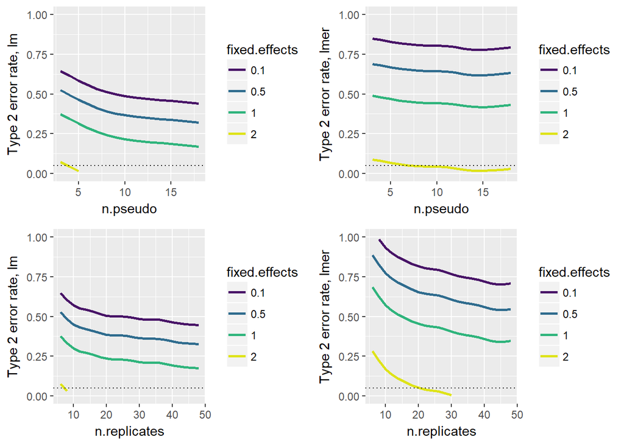

```r
p1 <- plot.error.rates(sims.meta, formula("as.numeric(lm > .05) ~ s(n.pseudo) + fixed.effects")) +
  ylab("Type 2 error rate, lm") +
  ylim(0, 1)
p2 <- plot.error.rates(sims.meta, formula("as.numeric(lmer > .05) ~ s(n.pseudo) + fixed.effects")) +
  ylab("Type 2 error rate, lmer") +
  ylim(0, 1)
p3 <- plot.error.rates(sims.meta, formula("as.numeric(lm > .05) ~ s(n.replicates) + fixed.effects")) +
  ylab("Type 2 error rate, lm") +
  ylim(0, 1)
p4 <- plot.error.rates(sims.meta, formula("as.numeric(lmer > .05) ~ s(n.replicates) + fixed.effects")) +
  ylab("Type 2 error rate, lmer") +
  ylim(0, 1)

grid.arrange(p1, p2, p3, p4, ncol = 2)
```

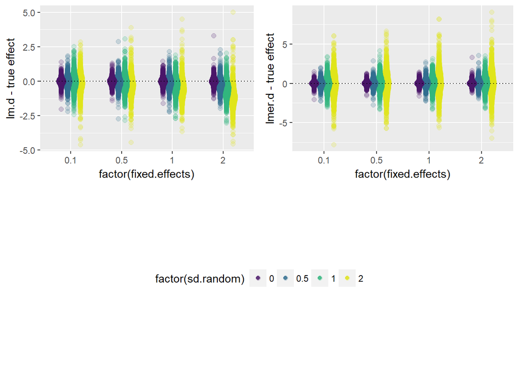

```r
p1 <- ggplot(sims.meta, aes(x = factor(fixed.effects), y = lm.d, colour = factor(sd.random))) +
  geom_quasirandom(dodge.width = 1/2, alpha = 1/5, size = 2) +
  geom_hline(yintercept = 0, linetype = "dotted") +
  theme(legend.position = "none") +
  ylab("lm.d - true effect")
p2 <- ggplot(sims.meta, aes(x = factor(fixed.effects), y = lmer.d, colour = factor(sd.random))) +
  geom_quasirandom(dodge.width = 1/2, alpha = 1/5, size = 2) +
  geom_hline(yintercept = 0, linetype = "dotted") +
  theme(legend.position = "none") +
  ylab("lmer.d - true effect")
p_leg <- get_legend(p2 + geom_point(alpha = 4/5) + theme(legend.position = "bottom"))
grid.arrange(p1, p2, p_leg, layout_matrix = rbind(c(1,2), c(3)))
```

# Type 1 error rates - nested design

```r
n.replicates <- floor(runif(n.sims, 6, 50)/2)*2 # even number between 6 and 40
n.pseudo <- sample(c(3:18), n.sims, replace = TRUE)
sd.error <- 1
random.assignment = FALSE
sd.random <- sample(c(0.5, 1, 2), n.sims, replace = TRUE)
fixed.effects <- 0  # no difference between groups

sims.meta <- data.frame(n.replicates = n.replicates,
                        n.pseudo = n.pseudo,
                        sd.error = sd.error,
                        random.assignment = random.assignment,
                        sd.random = sd.random,
                        fixed.effects = fixed.effects)

sims <- pmap(sims.meta, sim.mm)  # simulates a data-set using parameters from each row of sims.meta

x <- t(sapply(sims, function(x) tests(x, nested = TRUE)))
sims.meta$lm <- x[,1]
sims.meta$lmer <- x[,2]
sims.meta$lmer_slope <- x[,3]
sims.meta$lm.d <- x[,4] - sims.meta$fixed.effects
sims.meta$lmer.d <- x[,5] - sims.meta$fixed.effects
save(sims.meta, file = "sims_meta_no_effect_25000_nested.RData")
```

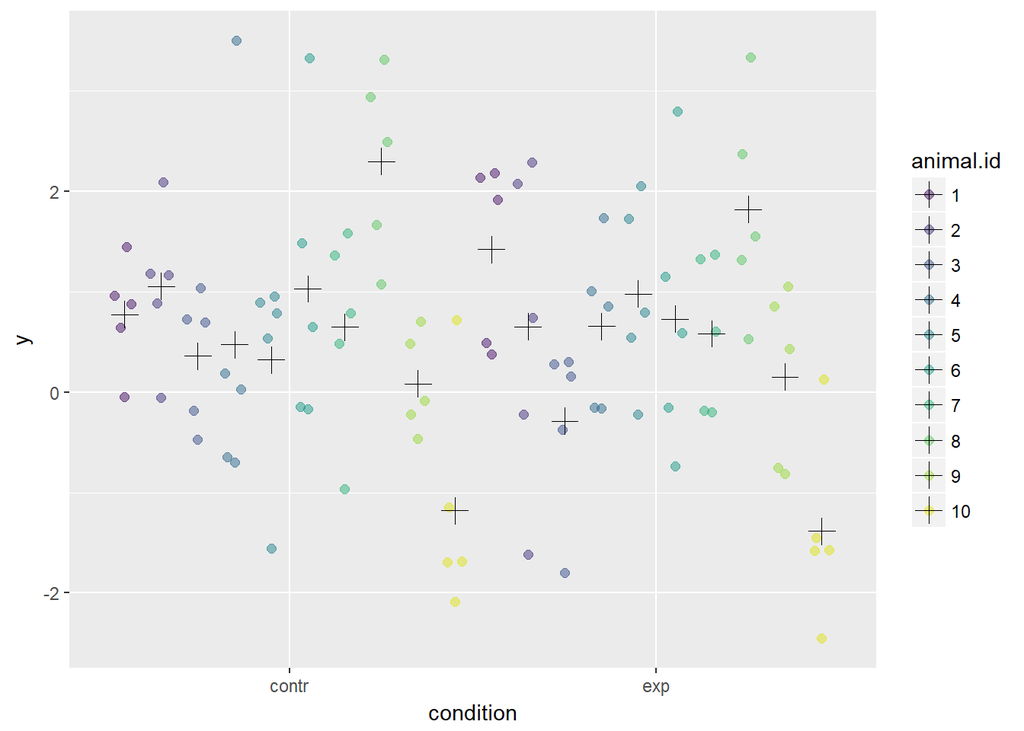

```r
## let's plot the first of these simulations and compare to the parameters as a sanity check
plot.sim(sims[[2L]])
```

```r
sims.meta[2L,]
```

```
##   n.replicates n.pseudo sd.error random.assignment sd.random fixed.effects
## 2           10        5        1             FALSE         1             0
```

#### Marginal Type 1 error rate:

```r
load("sims_meta_no_effect_25000_nested.RData")
sims.meta %>%
  summarise(type1.lm = mean(lm < .05), type1.lmer = mean(lmer < .05), type1.lmer.slope = mean(lmer_slope < .05))
```

```
##   type1.lm type1.lmer type1.lmer.slope
## 1  0.01136      0.051          0.03572
```

#### Type 1 error rate conditioning on variance of random effects:

```r
sims.meta %>%
  group_by(sd.random) %>%
  summarise(type1.lm = mean(lm < .05), type1.lmer = mean(lmer < .05), type1.lmer.slope = mean(lmer_slope < .05))
```

```
## # A tibble: 3 x 4
##   sd.random type1.lm type1.lmer type1.lmer.slope
##       <dbl>    <dbl>      <dbl>            <dbl>
## 1     0.500 0.0271       0.0526           0.0361
## 2     1.00  0.00668      0.0481           0.0327
## 3     2.00  0.000239     0.0523           0.0383
```

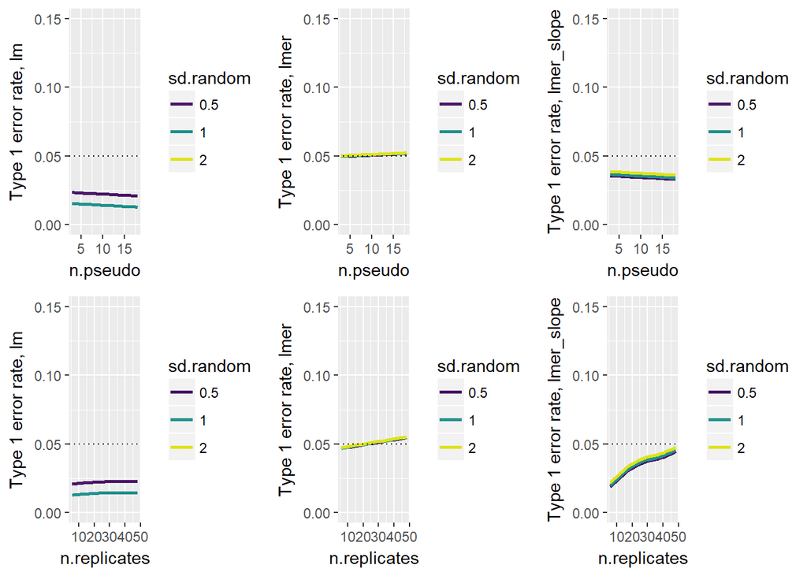

```r
p1 <- plot.error.rates(sims.meta, formula("as.numeric(lm < .05) ~ s(n.pseudo) + sd.random")) +
  ylab("Type 1 error rate, lm") +
  ylim(0, 0.15)
p2 <- plot.error.rates(sims.meta, formula("as.numeric(lmer < .05) ~ s(n.pseudo) + sd.random")) +
  ylab("Type 1 error rate, lmer") +
  ylim(0, 0.15)
p3 <- plot.error.rates(sims.meta, formula("as.numeric(lmer_slope < .05) ~ s(n.pseudo) + sd.random")) +
  ylab("Type 1 error rate, lmer_slope") +
  ylim(0, 0.15)
p4 <- plot.error.rates(sims.meta, formula("as.numeric(lm < .05) ~ s(n.replicates) + sd.random")) +
  ylab("Type 1 error rate, lm") +
  ylim(0, 0.15)
p5 <- plot.error.rates(sims.meta, formula("as.numeric(lmer < .05) ~ s(n.replicates) + sd.random")) +
  ylab("Type 1 error rate, lmer") +
  ylim(0, 0.15)
p6 <- plot.error.rates(sims.meta, formula("as.numeric(lmer_slope < .05) ~ s(n.replicates) + sd.random")) +
  ylab("Type 1 error rate, lmer_slope") +
  ylim(0, 0.15)

grid.arrange(p1, p2, p3, p4, p5, p6, ncol = 3)
```

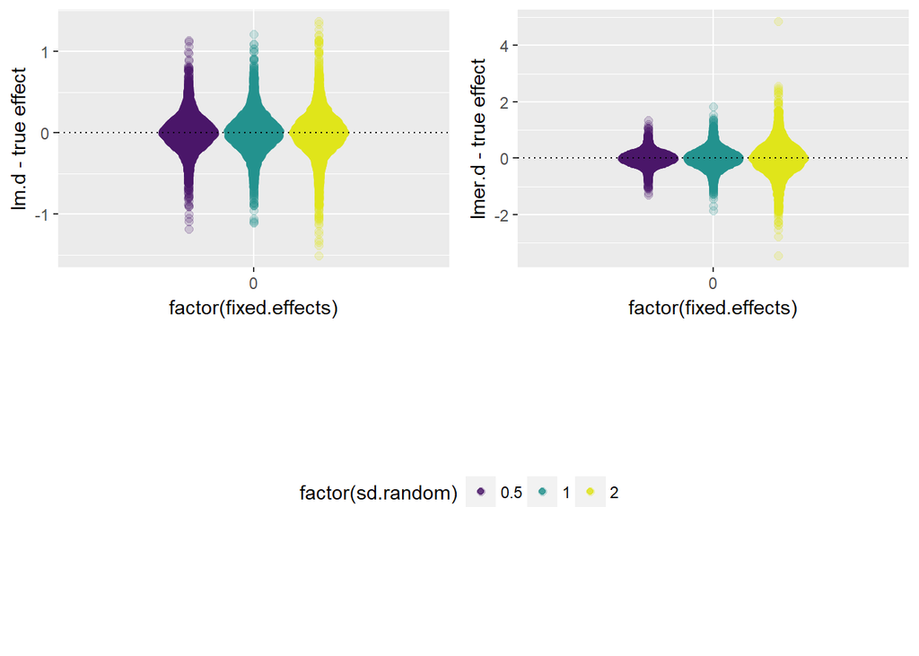

```r
p1 <- ggplot(sims.meta, aes(x = factor(fixed.effects), y = lm.d, colour = factor(sd.random))) +
  geom_quasirandom(dodge.width = 1/2, alpha = 1/5, size = 2) +
  geom_hline(yintercept = 0, linetype = "dotted") +
  theme(legend.position = "none") +
  ylab("lm.d - true effect")
p2 <- ggplot(sims.meta, aes(x = factor(fixed.effects), y = lmer.d, colour = factor(sd.random))) +
  geom_quasirandom(dodge.width = 1/2, alpha = 1/5, size = 2) +
  geom_hline(yintercept = 0, linetype = "dotted") +
  theme(legend.position = "none") +
  ylab("lmer.d - true effect")
p_leg <- get_legend(p2 + geom_point(alpha = 4/5) + theme(legend.position = "bottom"))
grid.arrange(p1, p2, p_leg, layout_matrix = rbind(c(1,2), c(3)))
```

# Type 2 error rates - nested design

```r
fixed.effects <- sample(c(0.1, 0.5, 1, 2), n.sims, replace = T)

n.replicates <- floor(runif(n.sims, 6, 50)/2)*2 # even number between 6 and 40
n.pseudo <- sample(c(3:18), n.sims, replace = TRUE)
sd.error <- 1
random.assignment = FALSE
sd.random <- sample(c(0.5, 1, 2), n.sims, replace = TRUE)

sims.meta <- data.frame(n.replicates = n.replicates,
                        n.pseudo = n.pseudo,
                        sd.error = sd.error,
                        random.assignment = random.assignment,
                        sd.random = sd.random,
                        fixed.effects = fixed.effects)

sims <- pmap(sims.meta, sim.mm)  # simulates a data-set using parameters from each row of sims.meta

x <- t(sapply(sims, function(x) tests(x, nested = TRUE)))
sims.meta$lm <- x[,1]
sims.meta$lmer <- x[,2]
sims.meta$lmer_slope <- x[,3]
sims.meta$lm.d <- x[,4] - sims.meta$fixed.effects
sims.meta$lmer.d <- x[,5] - sims.meta$fixed.effects
save(sims.meta, file = "sims_meta_range_effect_25000_nested.RData")
```

#### Marginal Type 2 error rate:

```r
load("sims_meta_range_effect_25000_nested.RData")
sims.meta %>%
  summarise(type2.lm = mean(lm > .05), type2.lmer = mean(lmer > .05), type2.lmer_slope = mean(lmer_slope > .05))
```

```
##   type2.lm type2.lmer type2.lmer_slope
## 1  0.27088    0.20548            0.229
```

#### Type 2 error rate conditioning on variance of random effects:

```r
sims.meta %>%
  group_by(sd.random) %>%
  summarise(type2.lm = mean(lm > .05), type2.lmer = mean(lmer > .05), type2.lmer_slope = mean(lmer_slope > .05))
```

```
## # A tibble: 3 x 4
##   sd.random type2.lm type2.lmer type2.lmer_slope
##       <dbl>    <dbl>      <dbl>            <dbl>
## 1     0.500    0.222      0.204            0.236
## 2     1.00     0.268      0.212            0.232
## 3     2.00     0.325      0.199            0.220
```

#### Type 2 error rate conditioning on fixed effect size:

```r
sims.meta %>%
  group_by(fixed.effects) %>%
  summarise(type2.lm = mean(lm > .05), type2.lmer = mean(lmer > .05), type2.lmer_slope = mean(lmer_slope > .05))
```

```
## # A tibble: 4 x 4
##   fixed.effects type2.lm type2.lmer type2.lmer_slope
##           <dbl>    <dbl>      <dbl>            <dbl>
## 1         0.100   0.917    0.776              0.817
## 2         0.500   0.153    0.0428             0.0737
## 3         1.00    0.0115   0.000955           0.0137
## 4         2.00    0.       0.                 0.0101
```

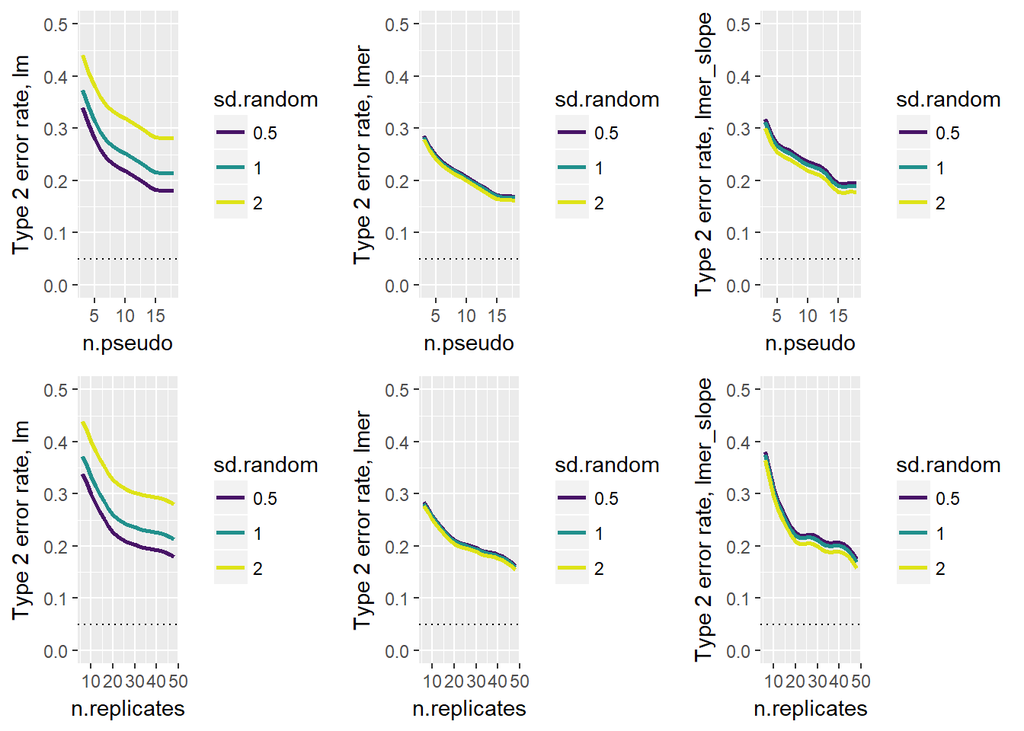

```r
p1 <- plot.error.rates(sims.meta, formula("as.numeric(lm > .05) ~ s(n.pseudo) + sd.random")) +
  ylab("Type 2 error rate, lm") +
  ylim(0, 0.5)
p2 <- plot.error.rates(sims.meta, formula("as.numeric(lmer > .05) ~ s(n.pseudo) + sd.random")) +
  ylab("Type 2 error rate, lmer") +
  ylim(0, 0.5)
p3 <- plot.error.rates(sims.meta, formula("as.numeric(lmer_slope > .05) ~ s(n.pseudo) + sd.random")) +
  ylab("Type 2 error rate, lmer_slope") +
  ylim(0, 0.5)
p4 <- plot.error.rates(sims.meta, formula("as.numeric(lm > .05) ~ s(n.replicates) + sd.random")) +
  ylab("Type 2 error rate, lm") +
  ylim(0, 0.5)
p5 <- plot.error.rates(sims.meta, formula("as.numeric(lmer > .05) ~ s(n.replicates) + sd.random")) +
  ylab("Type 2 error rate, lmer") +
  ylim(0, 0.5)
p6 <- plot.error.rates(sims.meta, formula("as.numeric(lmer_slope > .05) ~ s(n.replicates) + sd.random")) +
  ylab("Type 2 error rate, lmer_slope") +
  ylim(0, 0.5)

grid.arrange(p1, p2, p3, p4, p5, p6, ncol = 3)
```

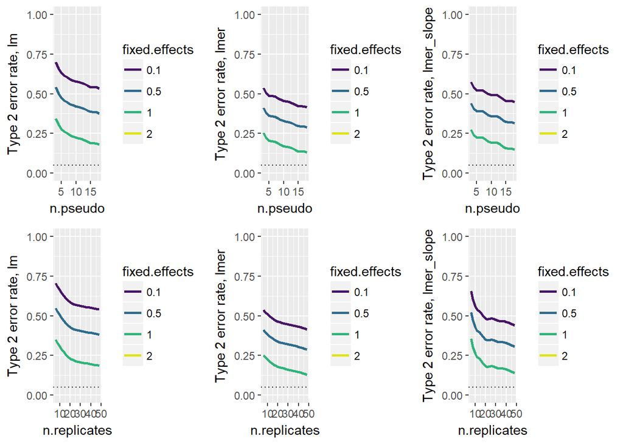

```r
p1 <- plot.error.rates(sims.meta, formula("as.numeric(lm > .05) ~ s(n.pseudo) + fixed.effects")) +
  ylab("Type 2 error rate, lm") +
  ylim(0, 1)
p2 <- plot.error.rates(sims.meta, formula("as.numeric(lmer > .05) ~ s(n.pseudo) + fixed.effects")) +
  ylab("Type 2 error rate, lmer") +
  ylim(0, 1)
p3 <- plot.error.rates(sims.meta, formula("as.numeric(lmer_slope > .05) ~ s(n.pseudo) + fixed.effects")) +
  ylab("Type 2 error rate, lmer_slope") +
  ylim(0, 1)
p4 <- plot.error.rates(sims.meta, formula("as.numeric(lm > .05) ~ s(n.replicates) + fixed.effects")) +
  ylab("Type 2 error rate, lm") +
  ylim(0, 1)
p5 <- plot.error.rates(sims.meta, formula("as.numeric(lmer > .05) ~ s(n.replicates) + fixed.effects")) +
  ylab("Type 2 error rate, lmer") +
  ylim(0, 1)
p6 <- plot.error.rates(sims.meta, formula("as.numeric(lmer_slope > .05) ~ s(n.replicates) + fixed.effects")) +
  ylab("Type 2 error rate, lmer_slope") +
  ylim(0, 1)

grid.arrange(p1, p2, p3, p4, p5, p6, ncol = 3)
```

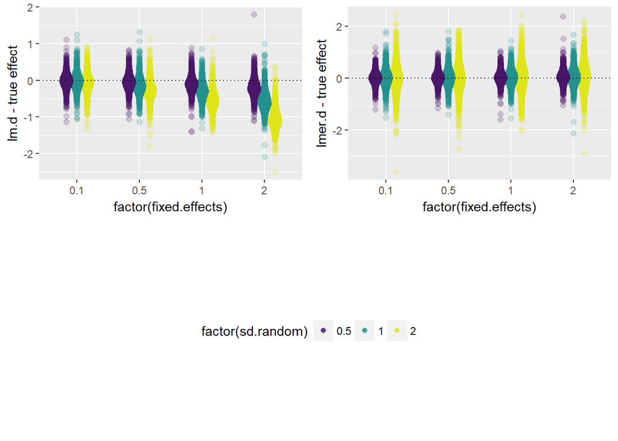

```r
p1 <- ggplot(sims.meta, aes(x = factor(fixed.effects), y = lm.d, colour = factor(sd.random))) +
  geom_quasirandom(dodge.width = 1/2, alpha = 1/5, size = 2) +
  geom_hline(yintercept = 0, linetype = "dotted") +
  theme(legend.position = "none") +
  ylab("lm.d - true effect")
p2 <- ggplot(sims.meta, aes(x = factor(fixed.effects), y = lmer.d, colour = factor(sd.random))) +
  geom_quasirandom(dodge.width = 1/2, alpha = 1/5, size = 2) +
  geom_hline(yintercept = 0, linetype = "dotted") +
  theme(legend.position = "none") +
  ylab("lmer.d - true effect")
p_leg <- get_legend(p2 + geom_point(alpha = 4/5) + theme(legend.position = "bottom"))
grid.arrange(p1, p2, p_leg, layout_matrix = rbind(c(1,2), c(3)))
```